# Week 6 - Teacher

Jerri Berry Danso

March 3, 2025

## Step 1

Load the tidyverse and educationdata packages. Like all packages, you will need to install the educationdata package before loading it for the first time.

```r
library(tidyverse)
library(educationdata)
```

## Step 2

*Note – this may take a few minutes (or more) to run! If it stops running, you may need to try again. If you have tried several times and cannot access the data, please message the instructors.*

```r
df <- get_education_data(
    level = "college-university",
    source = "ipeds",
    topic = "enrollment-headcount",
    filters = list(year = c(2018), level_of_study = "undergraduate")
)
```

```
##
## Fetching data for college-university/ipeds/enrollment-headcount/2018/undergraduate/? ...
```

[output not shown]

[output not shown]

[output not shown]

[output not shown]

[output not shown]

[output not shown]

[output not shown]

[output not shown]

[output not shown]

[output not shown]

[output not shown]

[output not shown]

[output not shown]

[output not shown]

[output not shown]

[output not shown]

[output not shown]

```r
df <- as_tibble(df)
```

In the next code chunk, please glimpse the data you accessed.

```r
glimpse(df)
```

```
## Rows: 179,160
## Columns: 7
## $ unitid         <int> 100654, 100654, 100654, 100663, 100663, 100663, 100690,…
## $ fips           <int> 1, 1, 1, 1, 1, 1, 1, 1, 1, 1, 1, 1, 1, 1, 1, 1, 1, 1, 1…
## $ year           <int> 2018, 2018, 2018, 2018, 2018, 2018, 2018, 2018, 2018, 2…
## $ level_of_study <int> 1, 1, 1, 1, 1, 1, 1, 1, 1, 1, 1, 1, 1, 1, 1, 1, 1, 1, 1…
## $ race           <int> 1, 1, 1, 1, 1, 1, 1, 1, 1, 1, 1, 1, 1, 1, 1, 1, 1, 1, 1…
## $ sex            <int> 1, 99, 2, 1, 99, 2, 1, 99, 2, 1, 99, 2, 1, 99, 2, 1, 99…
## $ headcount      <int> 61, 109, 48, 3426, 8299, 4873, 63, 113, 50, 3593, 6094,…
```

You may notice that instead of College or University names, you have an identifier that is a number, `unitid`. You can look up their names here: https://nces.ed.gov/ipeds/datacenter/InstitutionByName.aspx?stepId=1&sid=fb7e4c13-4a9e-43a5-89eb-dfead5e01d78&rtid=6

You can also use that link (above) to lookup the unitid for a school. Please find the University of Tennessee, Knoxville, unit ID. Then, below, use the `filter()` function to filter the data you already accessed to only include rows associated with the University of Tennessee, Knoxville. Here’s how that would be done.

```r
df_UTK <- df %>%
  filter(unitid == 221759)
df_UTK
```

```
## # A tibble: 30 × 7
##    unitid  fips  year level_of_study  race   sex headcount
##     <int> <int> <int>          <int> <int> <int>     <int>
##  1 221759    47  2018              1     1     1      9402
##  2 221759    47  2018              1     1    99     19041
##  3 221759    47  2018              1     1     2      9639
##  4 221759    47  2018              1     2     1       719
##  5 221759    47  2018              1     2    99      1528
##  6 221759    47  2018              1     2     2       809
##  7 221759    47  2018              1     3     1       487
##  8 221759    47  2018              1     3    99      1064
##  9 221759    47  2018              1     3     2       577
## 10 221759    47  2018              1     4     1       494
## # ℹ 20 more rows
```

## Step 3

How many colleges/universities are there in the data set? Please count up the number of unique colleges/universities using the tidyverse/tidyverse functions in the next code chunk.

```r
num_schools <- df %>%
  distinct(unitid) %>%
  count()
num_schools
```

```
## # A tibble: 1 × 1
##       n
##   <int>
## 1  5972
```

- There are 5,972 unique colleges/universities in the dataset.

## Step 4

To visualize the range of enrollments at all U.S. schools, let’s create a histogram of total enrollment. To do this, we need to check out the codebook: https://educationdata.urban.org/documentation/colleges.html#ipeds-enrollment-headcount

Note that values of 99 have a special meaning. What does it mean? Add a note below:

- 99 means total across all categories in that specific variable

Check out the `headcount` variable in the codebook to understand its meaning. Then, filter the data so that race and sex are both equivalent to 99. If you’ve successfully filtered the data, you should have only one row per unitid (college or university).

Then, create a histogram of the headcount variable *after* you have filtered the data.

Read about geom_histogram() here: https://ggplot2.tidyverse.org/reference/geom_histogram.html

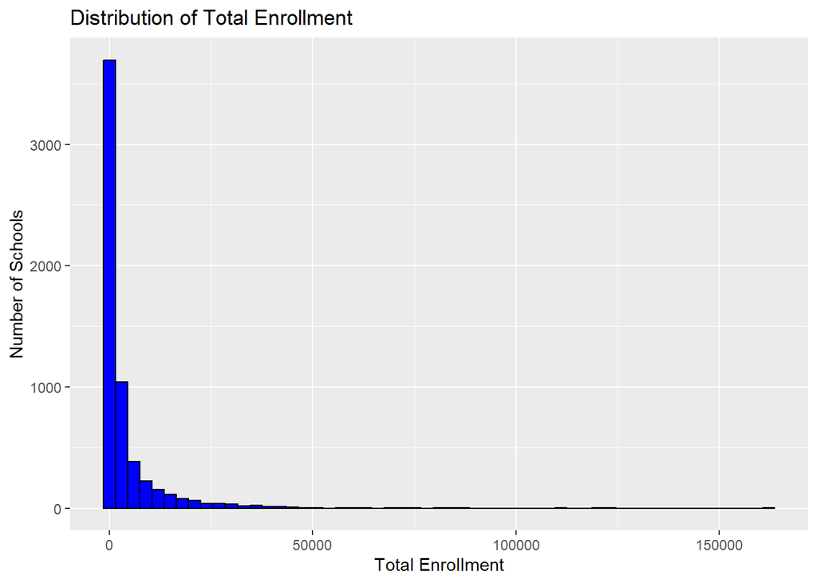

```r
df_filtered <- df %>%
  filter(race == 99, sex == 99)

ggplot(df_filtered, aes(x = headcount)) +
    geom_histogram(binwidth = 3000, fill = "blue", color = "black") +
    labs(title = "Distribution of Total Enrollment",
         x = "Total Enrollment",
         y = "Number of Schools")
```

Please interpret the graph you created. What do you notice? What does this tell you?

- The histogram is not normally distributed, and most institutions have enrollments that are clustered in a specific range. A few schools have extremely high enrollments (most likely large public universities).

## Step 5

Create your own data frame *using a different variable of your choosing*. Examine the options available on the educationdata GitHub: https://github.com/UrbanInstitute/education-data-package-r. Also, consider reviewing the EDP documentation: https://educationdata.urban.org/documentation/index.html.

At this stage, we are focused on becoming familiar with accessing data from the API, so don’t worry too much about the specifics of your selection.

```r
df_grad <- get_education_data(level = "college-university",
    source = "ipeds",
    topic = "grad-rates",
    filters = list(year = 2017))
```

```
##
## Fetching data for college-university/ipeds/grad-rates/2017/? ...
```

[output not shown]

[output not shown]

[output not shown]

[output not shown]

[output not shown]

[output not shown]

[output not shown]

[output not shown]

[output not shown]

[output not shown]

[output not shown]

[output not shown]

[output not shown]

[output not shown]

[output not shown]

[output not shown]

[output not shown]

[output not shown]

[output not shown]

[output not shown]

[output not shown]

```r
df_grad <- as_tibble(df_grad)
```

Why did you select the variables you selected?

- I was interested in investigating 6-year graduation rates of institutions, as this is a widely discussed topic in my current work

## Step 6

Complete a very brief, exploratory analysis of your date. This can be *very* simple; just learn something about the data you accessed. recall again that the purpose of this step is to get familiar with accessing data from the API.

```r
#find summary of 6-year graduation rate
summary(df_grad$completion_rate_150pct)
```

```
##    Min. 1st Qu.  Median    Mean 3rd Qu.    Max.    NA's
##    0.00    0.23    0.48    0.47    0.70    1.00   72481
```

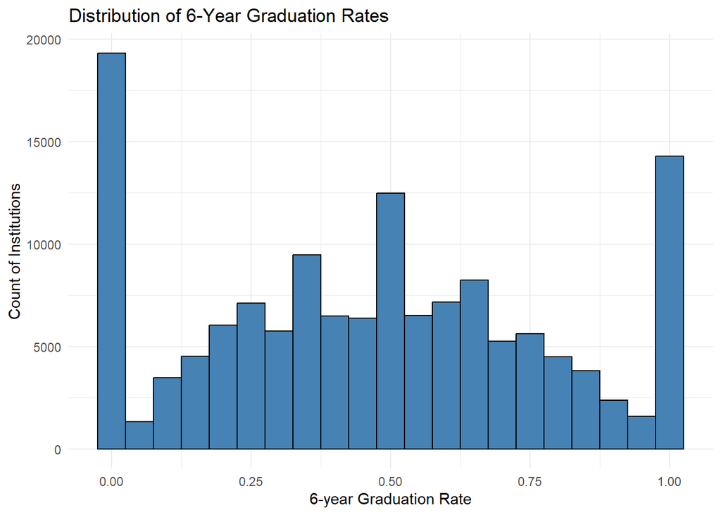

```r
#remove missing data from variable
df_grad_clean <- df_grad %>%
    filter(!is.na(completion_rate_150pct), completion_rate_150pct >= 0)

#create histogram
ggplot(df_grad_clean, aes(x = completion_rate_150pct)) +
    geom_histogram(binwidth = 0.05, fill = "steelblue", color = "black") +
    labs(title = "Distribution of 6-Year Graduation Rates",
         x = "6-year Graduation Rate",
         y = "Count of Institutions") +
    theme_minimal()
```

What information did you learn from your analysis? Were there any results that surprised you?

## Reach

This portion of the assignment is optional but offers you a chance to push your skills further.

Think of an issue University of Tennessee, Knoxville Chancellor Donde Plowman might be interested in. Create a new data frame that could be presented to Donde Plowman to address this interest. Complete a simple analysis to hep Donde understand what the data is saying.

- I would have investigated graduation rates for this prompt, but I already addressed it in step #6 above. Instead, I will use net price. College affordability is a hot topic in higher education, and I imagine this would be relevant to the university’s chancellor.

```r
df_netprice <- get_education_data(level = "college-university",
    source = "ipeds",
    topic = "sfa-grants-and-net-price",
    filters = list(year = 2021))
```

```
##
## Fetching data for college-university/ipeds/sfa-grants-and-net-price/2021/? ...
```

```
## Processing page 2 out of 4
```

```
## Processing page 3 out of 4
```

```
## Processing page 4 out of 4
```

```r
df_netprice <- as_tibble(df_netprice)

df_netprice %>%
  filter(unitid == 221759) %>%
  select(unitid, net_price)
```

```
## # A tibble: 7 × 2
##   unitid net_price
##    <int>     <int>
## 1 221759     21880
## 2 221759     26950
## 3 221759     25767
## 4 221759        NA
## 5 221759     21897
## 6 221759     14847
## 7 221759     10518
```

```r
df_netprice
```

```
## # A tibble: 37,009 × 15
##    unitid  year  fips  ftpt level_of_study degree_seeking class_level
##     <int> <int> <int> <int>          <int>          <int>       <int>
##  1 100654  2021     1     1              1              1           1
##  2 100654  2021     1     1              1              1           1
##  3 100654  2021     1     1              1              1           1
##  4 100654  2021     1     1              1              1           1
##  5 100654  2021     1     1              1              1           1
##  6 100654  2021     1     1              1              1           1
##  7 100654  2021     1     1              1              1           1
##  8 100663  2021     1     1              1              1           1
##  9 100663  2021     1     1              1              1           1
## 10 100663  2021     1     1              1              1           1
## # ℹ 36,999 more rows
## # ℹ 8 more variables: tuition_type <int>, type_of_aid <int>,
## #   income_level <int>, average_grant <int>, number_of_students <int>,
## #   total_grant <int>, net_price <int>, number_receiving_grants <int>
```

## Rubric

|  | Points Possible | Points Earned |
| --- | --- | --- |
| File knits | 2 |  |
| Code is accurately filled in for all 5 steps. | 10 |  |
| Steps 1-6 are completed | 3 points each |  |

## Knit and Submit

Complete the following steps to knit and publish your work:

1. First, change the name of the `author:` in the [YAML header](https://bookdown.org/yihui/rmarkdown-cookbook/rmarkdown-anatomy.html#yaml-metadata) at the very top of this document to your name. The YAML header controls the style and feel for knitted document but doesn’t actually display in the final output.
2. Next, click the knit button in the toolbar above to “knit” your R Markdown document to a [HTML](https://bookdown.org/yihui/rmarkdown/html-document.html) file that will be saved in your R Project folder. You should see a formatted webpage appear in your Viewer tab in the lower right pan or in a new browser window. Let’s us know if you run into any issues with knitting.
3. Upload the HTML file that is now present in the same folder as this R Markdown file to Canvas to receive credit for this assignment!